# Act Report

> This is the report that gives a breakdown on the data analysis process. During the course of this project I was able able to identify the following: Insights which were obtained from the data and also observations that were made from the visualization

Analysis and Visualization: At this point, data was analyzed to understand what value it has.

# Insights from the data:

In this section the main focus was to identify some insights or deducctions that can seen in the data. The insights were mainly obtained from grouping the data according to the top 9 tweeets and the least 9 tweets, also the top 9 retweets was also looked at.

1. The post "Here's a super supportive puppo participating in the Toronto #WomensMarch today" had the most likes
2. The least liked post was '@serial @MrRoles OH MY GOD I listened to all of season 1 during a single road trip. I love you guys! I can confirm Bernie's' had eight zero counts.
3. The post "Here's a doggo realizing you can stand in a pool. 13/10 enlightened af (vid by Tina Conrad)" Had the most retweets

# Observation from the Analysis:

At this stage of the project I performed data visualization on the clean data obtained. The two main visuals was a bar chart and a pie chart.

1. In this analysis, the efficiency of the various prediction methods was analyzed. This was to establish which of these prediction methods performed best, that is comparing their success rate. From the chart, it is clear that prediction method 2 had the best success rate among the three methods of prediction.

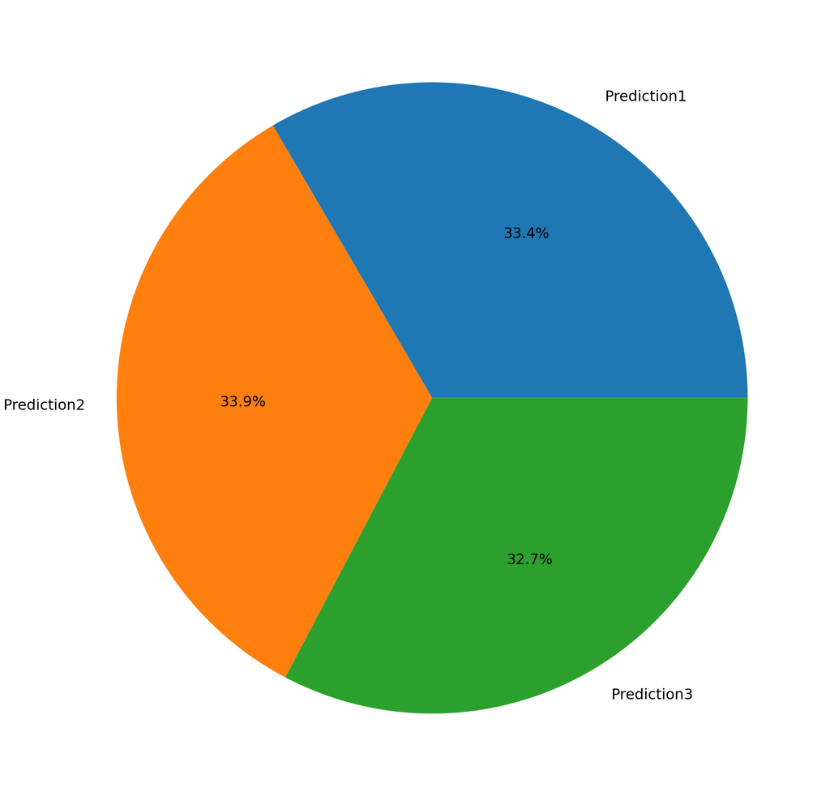

1. From the above visuals, dog breeds from each prediction were plotted against a favorite number of tweets. It was evident in the graph that some dog breeds from each prediction, that is dog breeds Lakeland Terrier,Laborer_retriever, Irish_Terrier from prediction1,prediction2,prediction3 respectively had the most likes. This essentially means that these breeds of dogs were popular.

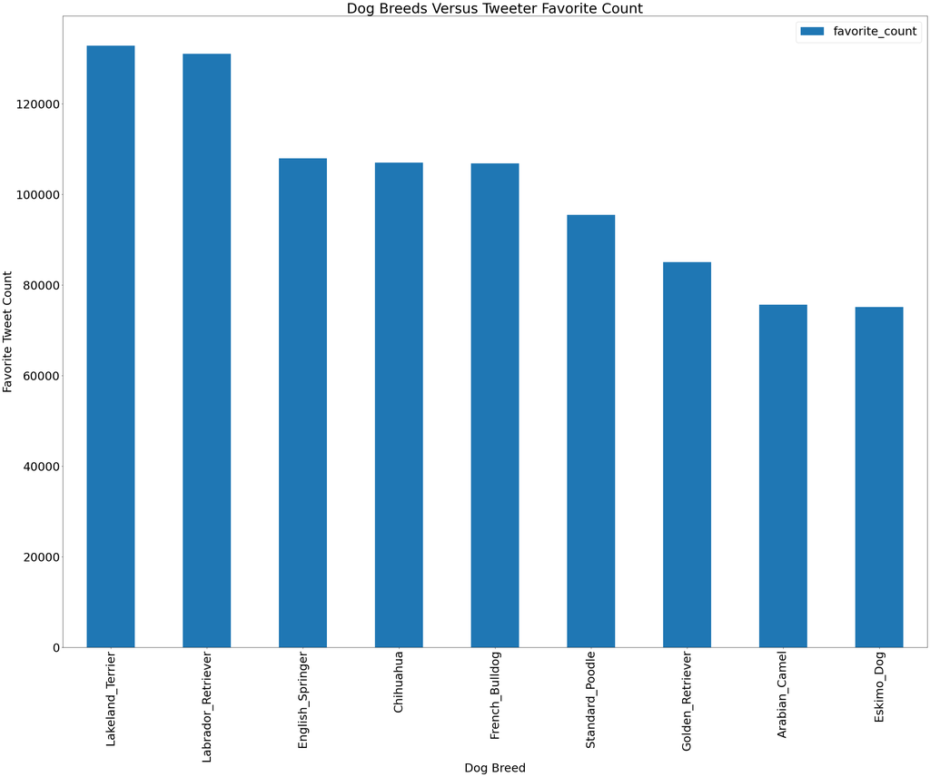

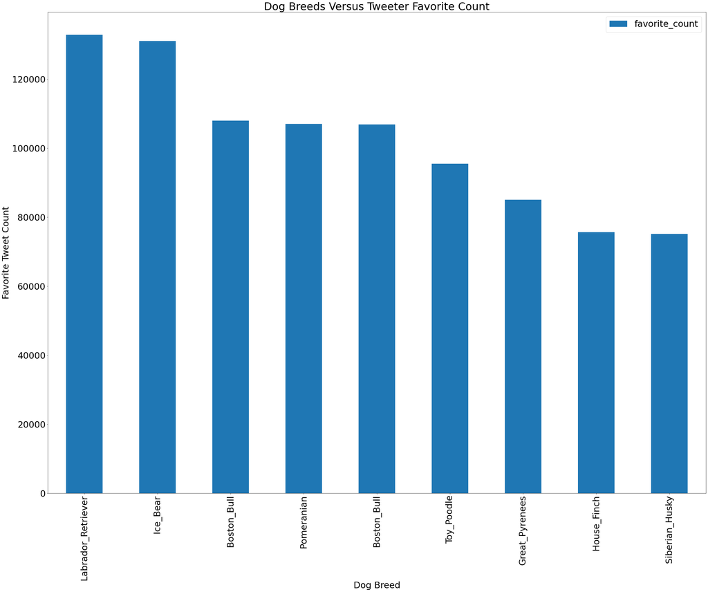

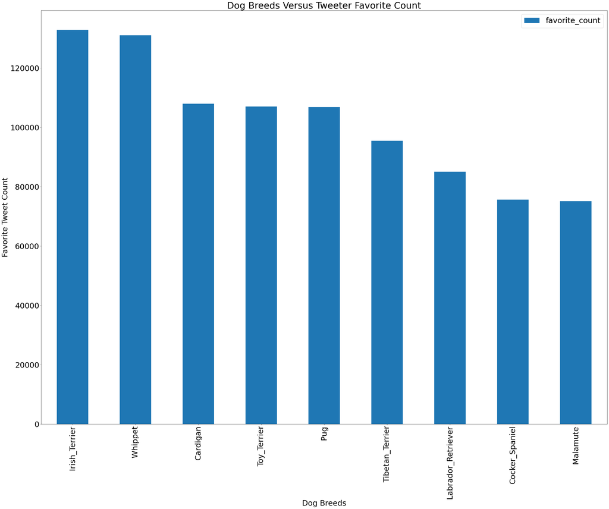